# assignment 10

Selina Joy Frei

2024-05-11

Download and decompress the following archive: https://ethz-ins.org/content/w10.assignment.zip This contains the bigwig files and peaks (bed) files for three TFs of the CREB family (all restricted to chr1; aligned against the hg38 genome) Use clustering and visualization to illustrate the relationship between the binding of the different proteins Use enrichment analysis (either GO or motif) on at least one of the clusters Write a paragraph describing your results

```r
suppressPackageStartupMessages({
  library(GenomicRanges)
  library(epiwraps)
  library(ggplot2)
  library(rGREAT) # Gene Ontology enrichment among genomic regions
})
```

## Download the data

```r
options(timeout = 6000)
download.file("https://ethz-ins.org/content/w10.assignment.zip", "w10.assignment.zip")
unzip("w10.assignment.zip")
list.files()
```

## Prepare the regions and the tracks –> read into a signal matrix

```r
peaks <- list.files(pattern="bed$")
peaks <- lapply(peaks, rtracklayer::import.bed)
peaks <- lapply(peaks, FUN=function(x) x[x$score>800])
tracks <- list.files(pattern="bw$")
regions <- reduce(unlist(GRangesList(peaks)))
```

## Prepare a summarized experiment and plot the heatmaps

```r
ese <- signal2Matrix(tracks, regions, extend=2000)
```

```
## Reading Creb1.bw
```

```
## Reading Creb3.bw
```

```
## Reading Creb3L1.bw
```

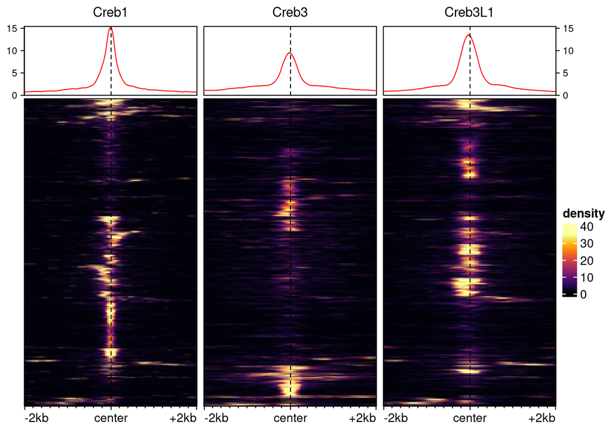

```r
plotEnrichedHeatmaps(ese, cluster_rows = TRUE)
```

## Clustering top down –> preserves better overall patterns

```r
set.seed(123)  # to ensure that it gives the same results every time because not deterministic
cl <- clusterSignalMatrices(ese, k=4) # for each row it says which cluster it belongs to
```

```
##   ~65% of the variance explained by clusters
```

```r
table(cl)
```

```
## cl
##   1   2   3   4
## 897 194 448 730
```

```r
head(cl)
```

```
## [1] 4 1 1 1 1 1
## Levels: 1 2 3 4
```

```r
length(cl)
```

```
## [1] 2269
```

```r
length(regions)
```

```
## [1] 2269
```

```r
rowData(ese)$cluster <- cl #store it such that if we change any order in the object, the cluster order will also be updated
```

Plotting the clusters:

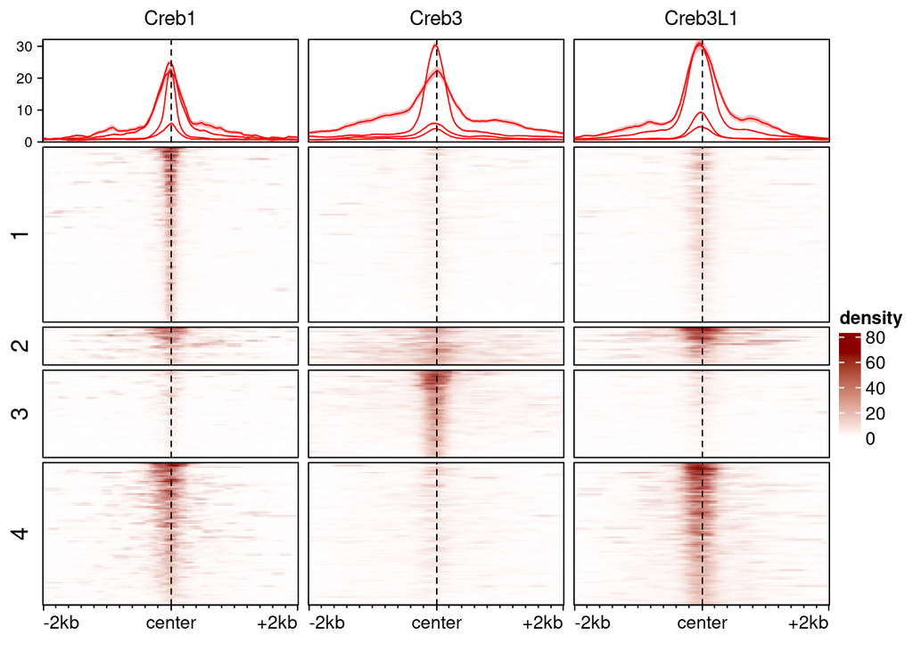

```r
plotEnrichedHeatmaps(ese, row_split=cl, trim=0.99,
                     colors=c("white","darkred"))
```

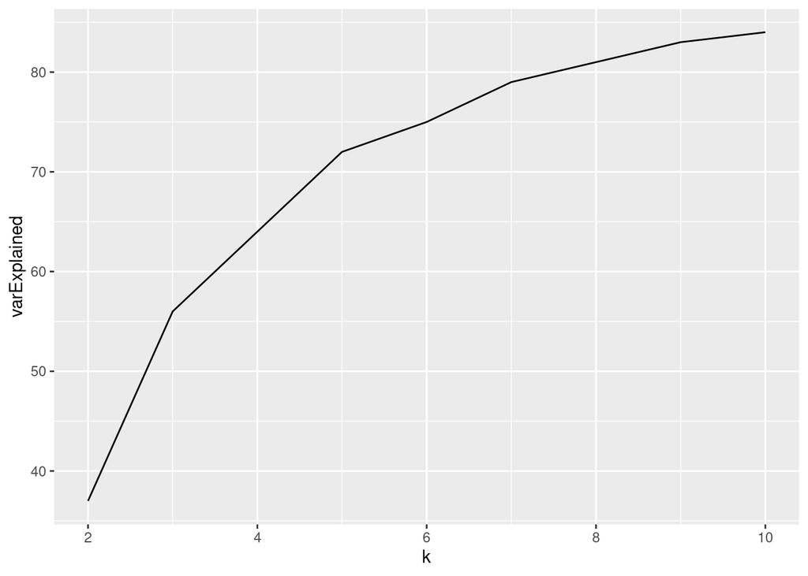

```r
# if we don't know how many clusters are good
cl2 <- clusterSignalMatrices(ese, k=2:10)
ggplot(cl2$varExplained, aes(k, varExplained)) + geom_line()
```

Adding colors:

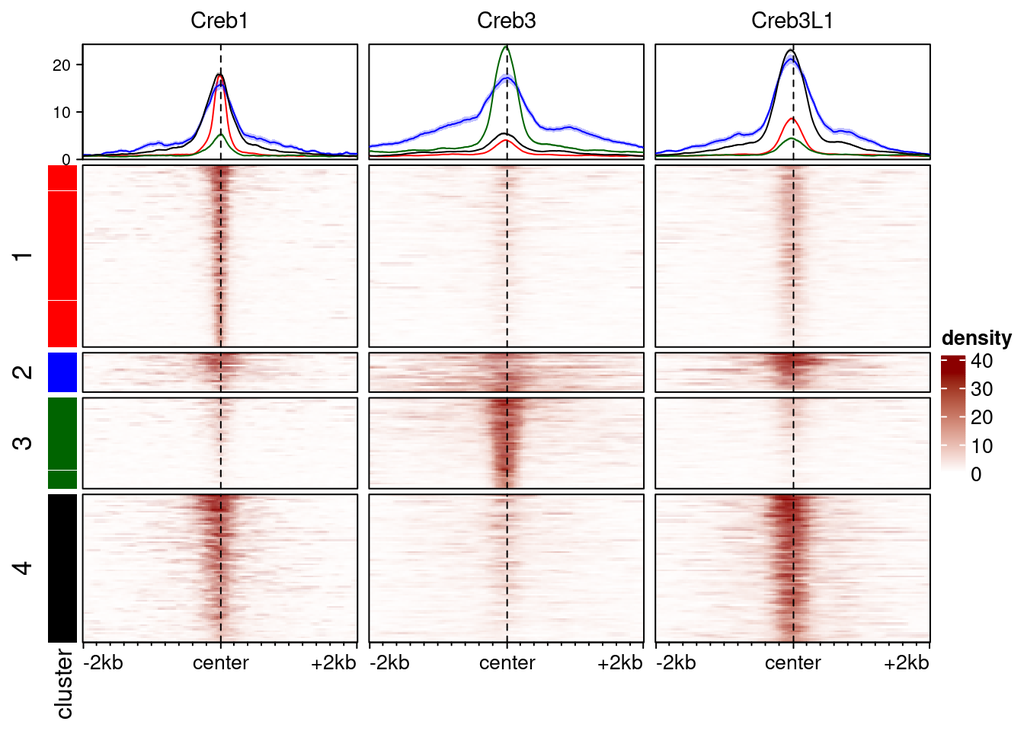

```r
mycolors <- c("1"="red", "2"="blue", "3"="darkgreen", "4"="black")
plotEnrichedHeatmaps(ese, row_split=cl, mean_color=mycolors, colors=c("white","darkred"))
```

Plotting just the averages:

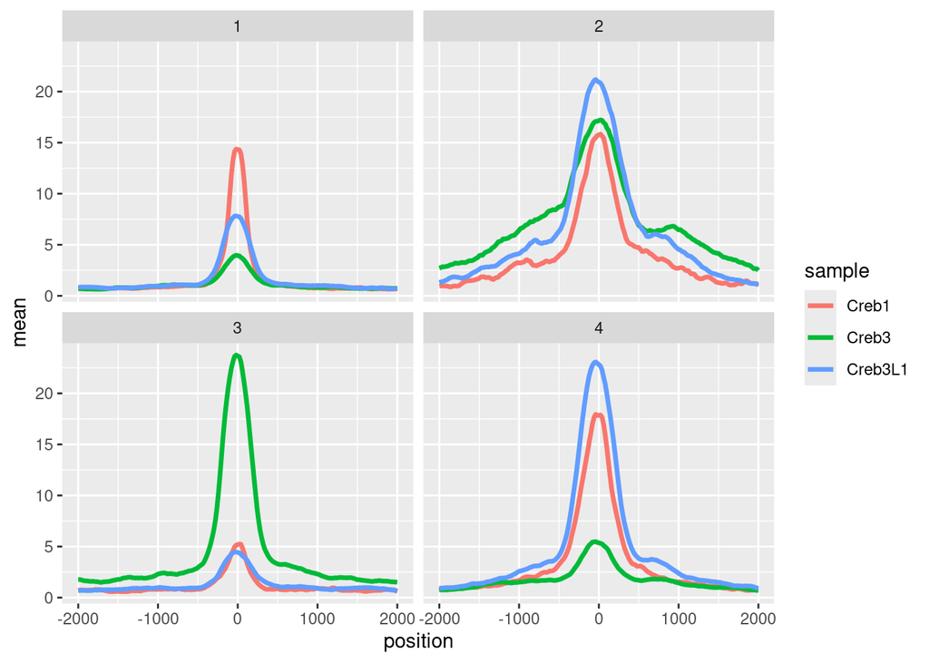

```r
d <- meltSignals(ese, splitBy=cl) # plot only average profiles of each cluster
# compute average across clusters (splitBy)
ggplot(d, aes(position, mean, colour=sample)) + geom_line(size=1.2) + facet_wrap(~split)
```

Clustering using relative signal instead to get more distinct signals:

```r
cl <- clusterSignalMatrices(ese, k=4, scaleRows = TRUE)
```

```
##   ~86% of the variance explained by clusters
```

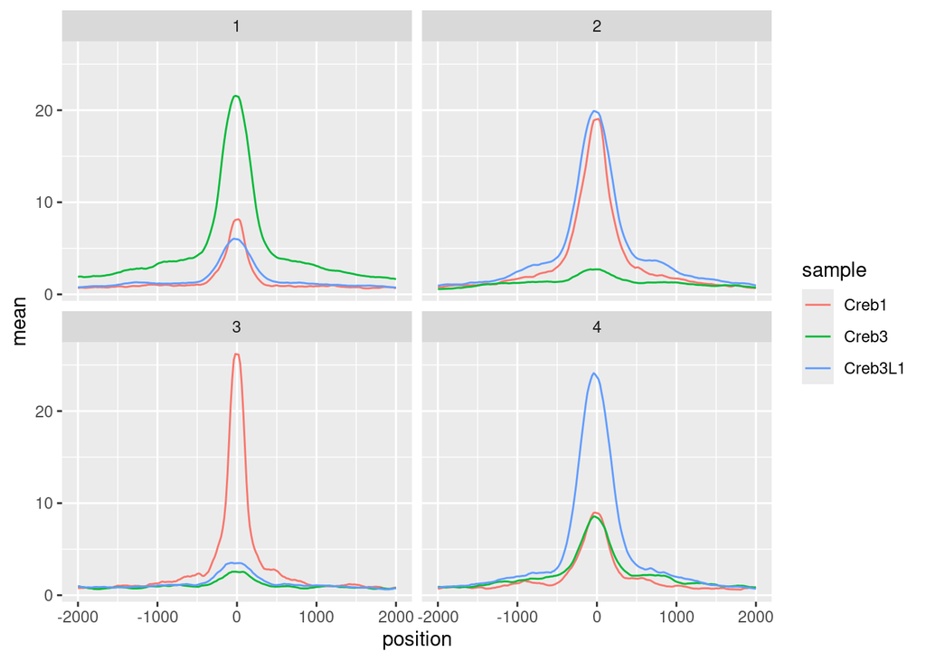

```r
d <- meltSignals(ese, splitBy=cl)
ggplot(d, aes(position, mean, colour=sample)) + geom_line() + facet_wrap(~split)
```